# Spatial R course day 1. Introduction to spatial analyses

## 8) Plotting mammal diversity

In the exercise above we counted the number of occurrence points for each cell of a given raster. Now we are going to use the information of many individual presence/absence rasters (cells coded as 1 or 0) for all mammal species and add the values in each cell across all rasters in order to plot a map of global mammal diversity.

As input data we are going to use the “present natural” rasters, which was produced generated as part of the database Phylacine which is a project I have been heavy involved in since ~2013. For this project we estimated ranges of each mammal species under a scenario of no human disturbance (i.e. where the species would occur today in a scenario where no human modifications of ranges has happened for the last 130,000 years).

The data is available via the [Phylacine database](https://megapast2future.github.io/PHYLACINE_1.2/ Click on the link in the ‘Download the data’ section to start the download. Unzip the downloaded file and copy it into your data folder that you downloaded from the course GutHub repo. The raster data we’re after is stored in the `Data/Ranges/Present_natural/` folder (Windows users remmeber to replace all `/` with `\\`). You can see all files that are present in that folder using the `list.files()` command. We will also be using a metadata file called spatial metadata. You will see that it contains a lot of information which we will not go into here and we will only use its taxonomic skeleton:

```r
head(list.files('C:\\Bpoxsync\\Phylacine\\1.21\\Data\\Ranges\\Present_natural\\'))
```

```
## [1] "Abditomys_latidens.tif"   "Abeomelomys_sevia.tif"
## [3] "Abrawayaomys_ruschii.tif" "Abrocoma_bennettii.tif"
## [5] "Abrocoma_boliviensis.tif" "Abrocoma_budini.tif"
```

```r
METADATA=read.csv("C:\\Bpoxsync\\Phylacine\\1.21\\Data\\Ranges\\Spatial_metadata.csv")
summary(METADATA)
```

```
##  Binomial.1.2        Order.1.2          Family.1.2         Genus.1.2
##  Length:5831        Length:5831        Length:5831        Length:5831
##  Class :character   Class :character   Class :character   Class :character
##  Mode  :character   Mode  :character   Mode  :character   Mode  :character
##
##
##
##  Species.1.2        Certainty.Level    Modification        Motivation
##  Length:5831        Length:5831        Length:5831        Length:5831
##  Class :character   Class :character   Class :character   Class :character
##  Mode  :character   Mode  :character   Mode  :character   Mode  :character
##
##
##
##  Last.Manual.Present.Natural.Modification Number.Cells.Current.Range
##  Length:5831                              Min.   :    0.0
##  Class :character                         1st Qu.:    6.0
##  Mode  :character                         Median :   39.0
##                                           Mean   :  341.4
##                                           3rd Qu.:  188.0
##                                           Max.   :37542.0
##  Number.Cells.Present.Natural.Range Change.In.Cells
##  Min.   :    0.0                    Min.   :-14047.00
##  1st Qu.:   11.0                    1st Qu.:     0.00
##  Median :   52.0                    Median :     0.00
##  Mean   :  379.1                    Mean   :    37.77
##  3rd Qu.:  226.5                    3rd Qu.:     0.00
##  Max.   :37542.0                    Max.   :  9239.00
```

```r
head(METADATA)
```

```
##           Binomial.1.2 Order.1.2  Family.1.2    Genus.1.2 Species.1.2
## 1   Abditomys_latidens  Rodentia     Muridae    Abditomys    latidens
## 2    Abeomelomys_sevia  Rodentia     Muridae  Abeomelomys       sevia
## 3 Abrawayaomys_ruschii  Rodentia  Cricetidae Abrawayaomys     ruschii
## 4   Abrocoma_bennettii  Rodentia Abrocomidae     Abrocoma   bennettii
## 5 Abrocoma_boliviensis  Rodentia Abrocomidae     Abrocoma boliviensis
## 6      Abrocoma_budini  Rodentia Abrocomidae     Abrocoma      budini
##                                                                             Certainty.Level
## 1 3) Merger of likely human caused disjunct ranges by filling intervening suitable habitats
## 2                                          0) Present Natural range identical to IUCN range
## 3                                          0) Present Natural range identical to IUCN range
## 4                                          0) Present Natural range identical to IUCN range
## 5                                          0) Present Natural range identical to IUCN range
## 6                                          0) Present Natural range identical to IUCN range
##               Modification                                    Motivation
```

[output cut: 20 more lines]

The folder contains a separate raster file for each species. To read a raster file we can just use the `raster()` function and the file name. We could e.g. want to read it the raster for wolf (canis_lupus), where the file would be called “canis_lupus.tif” In this and the other rasters in the folder, presense is coded as 1 and absense is coded as 0

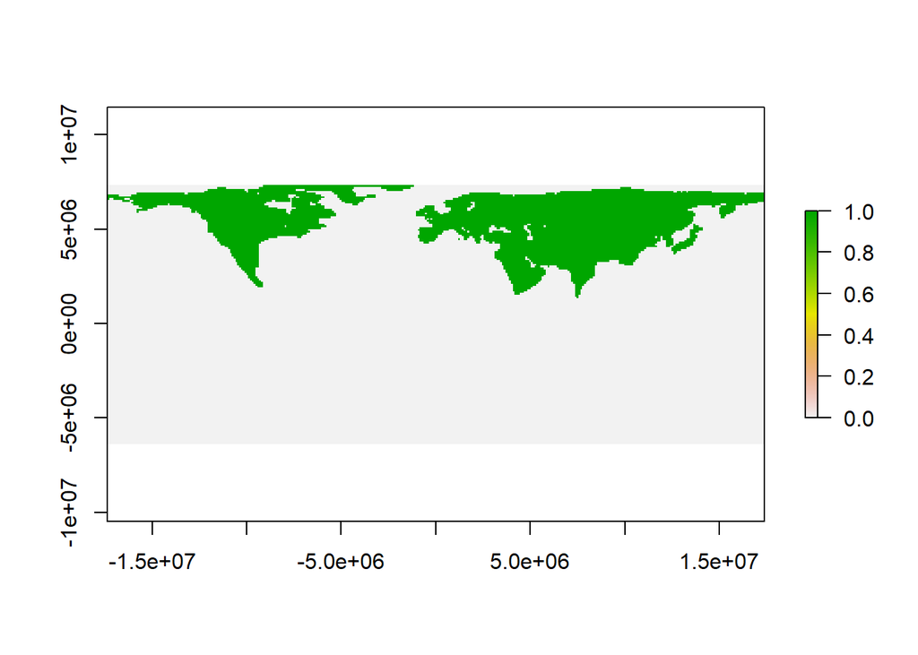

```r
Wolf = raster("C:\\Bpoxsync\\Phylacine\\1.21\\Data\\Ranges\\Present_natural\\canis_lupus.tif")
plot(Wolf)
```

We will here instead create rasters for a number of species. In this code we will create a diversity map for all species of bears (family Ursidae) but you can change it to any other group you like. As part of this we will rely on the command paste0(). This is a command which is used to write a specific string of text and is often useful in loops involving reading and writing to files. Let us first show how to read and plot the first species. We will be relying on the species name stored as Binomial.1.2 and the description of the group which in this case is stored as Family.1.2 but depending on the group you focus on it could be relevant to rely on Order.1.2 or Genus.1.2 instead.

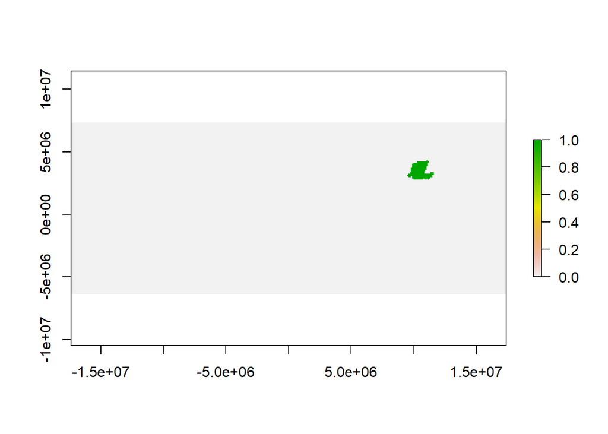

```r
Selected_species=METADATA$Binomial.1.2[METADATA$Family.1.2=="Ursidae"]
filepath ="C:\\Bpoxsync\\Phylacine\\1.21\\Data\\Ranges\\Present_natural\\"
Raster1=raster(paste0(filepath, Selected_species[1], ".tif"))
plot(Raster1)
```

This gave us the range of the first species (which is this case is the giant panda). Now let us instead read in all the species fullfilling our criteria. For this we can simply iterate through all raster files (using a `for(){}` loop, see [here](https://rspatial.org/intr/10-flow.html#for-loops) for a quick tutorial on for-loops in R). We initially create a list() to store the data but afterwards we will transform the data into a rasterstack. Finally we calculate the diversity raster as the sum of all the rasters in the stack

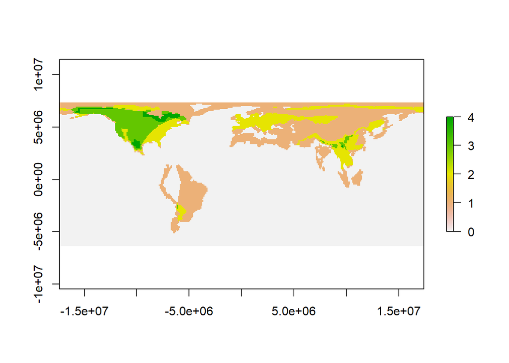

```r
RASTERS=list()
for (i in 1:length(Selected_species)) {
    RASTERS[i]=raster(paste0(filepath, Selected_species[i], ".tif"))
}
RASTERS = stack(RASTERS)
Diversity_raster=sum(RASTERS)
plot(Diversity_raster)
```

You can already see that diversity of any group you have chosen is distributed unevenly across the globe. However, we have not yet delimited the geographic features, the only reason why you can see where the continents are placed is because the structure of the diversity data. Now we want to delimit land from water, by plotting a world-map polygon on top of this raster.

Load the world map stored at `global\\ne_50m_land` and turn it into a spatial object.

```r
library(sf)
world = st_read("C:\\Bpoxsync\\Spatial_R\\Data\\global\\ne_50m_land\\ne_50m_land.shp")
world_spatial = as(world, 'Spatial')
```

Task: Now plot the world polygon on top of the raster data (hint: it’s supposed to not work out properly, see next section).

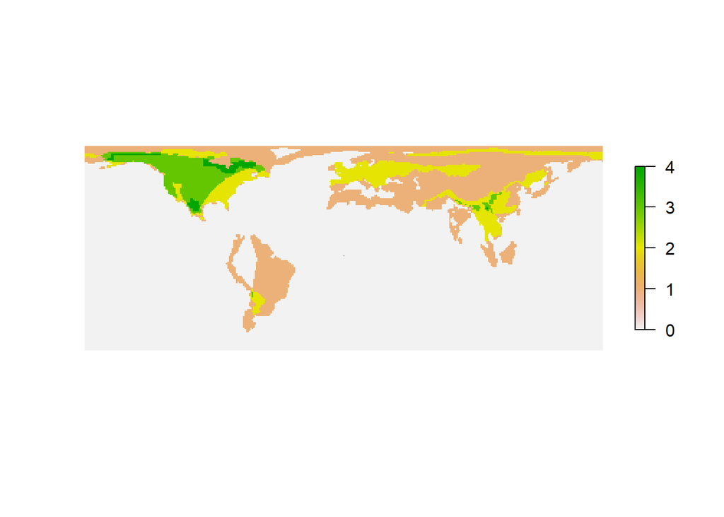

### Transforming coordinate system

What went wrong here? Do you see the little black dot in the center of the plot? That’s our world polygon! It looks like the coordinate system of our raster data does not match with that of the world map polygon (different coordinate reference systems). Let’s check the projections of the two objects:

```r
projection(Diversity_raster)
```

```
## [1] "+proj=cea +lat_ts=30 +lon_0=0 +x_0=0 +y_0=0 +datum=WGS84 +units=m +no_defs"
```

```r
projection(world_spatial)
```

```
## [1] "+proj=longlat +datum=WGS84 +no_defs"
```

```r
transformed_world = st_transform(world,projection(Diversity_raster))
transformed_world_spatial = as(transformed_world, 'Spatial')
```

Let’s see what the plot looks like now:

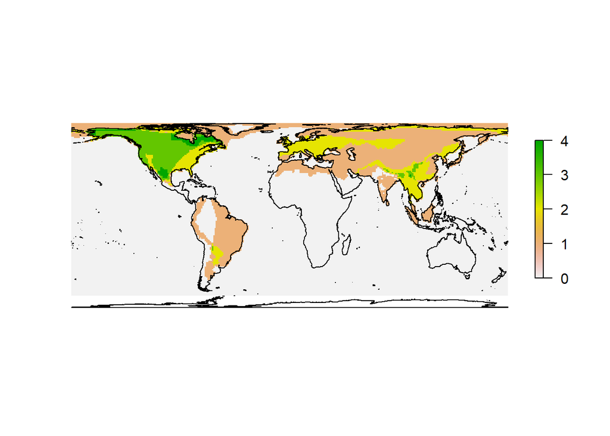

```r
plot(Diversity_raster,axes=F,box=FALSE)
plot(transformed_world_spatial,add=T)
```

### Using mask function to make cell selection

Note that we need to transform the selected country object first so it matches the projection of the raster. You should already know how this is done so I am not providing the codes. **In my future codes I will call the transformed country country_transformed_spatial , you can use another name but that requires you to change the code later when I am referring to country_transformed_spatial**

We can now create a raster only containing the Swedish part of the raster using mask(), and after this plot the results.

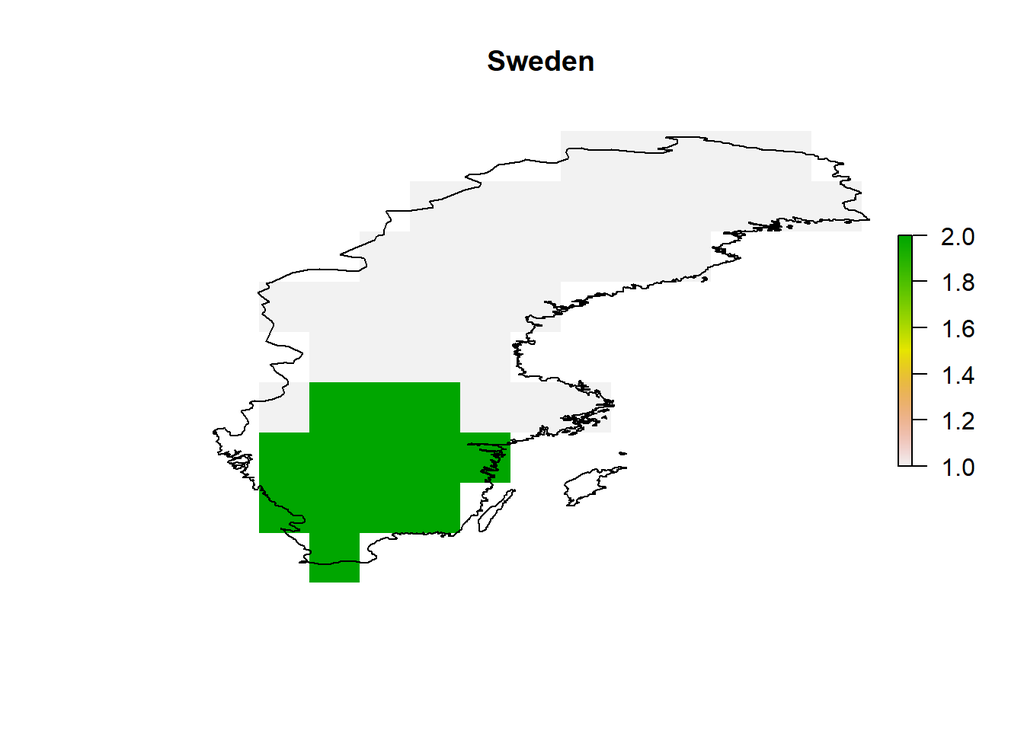

```r
country_cells = mask(Diversity_raster,country_transformed_spatial)

plot(country_transformed_spatial,main=country)
plot(country_cells,add=T)
plot(country_transformed_spatial,add=T)
```

In this particular case you can see that the present-natural diversify in southern Sweden would be two species (which would be the brown bear and the extinct cave bear), while the natural diversity of the rest of Sweden would be a single species. Your maps will of course be different depending on the organism group and country you are plotting.

You can store the plot as a pdf file to look at it in some more detail: As default it will create the folder in your default working directory. But you can change it to wherever you want to story it on your computer. In R this works by first creating a pdf with the command **pdf()**. After this all files are plotted to this file rather than the plotting window. When you are done plotting you write the link **dev.off()** which finishes the pdf file.

```r
pdf("Diversity.pdf")
plot(country_transformed_spatial,main=country)
plot(country_cells,add=T)
plot(country_transformed_spatial,add=T)
dev.off()
```

### Transform matrix of coordinates into desired projection

What if we want to transform a matrix of coordinates that we have loaded into R into any given projection? For example let’s try to plot the `species_occurrences` data from earlier on the transformed map from the previous section.

You will already hvae created a *SpatialPoints* object of records of a group of carnivores but since it was as a task I do not know what you called the object so we will create a new one here

```r
Mustelidae=Carnivora_Data[Carnivora_Data$family=="Mustelidae",]
locations = cbind(Mustelidae$decimalLongitude, Mustelidae$decimalLatitude)
species_occurrences <- SpatialPoints(locations)
dev.off()
```

We first need to tell R what projection our coordinates are currently in. You might find this information stored in the metadata that came with your occurrence files or if you collected the data yourself you may be able to find the information in the settings of your GPS device. However, if you have no idea what the projection of your coordinates is, look at the values of your coordinates and try to make out waht reference system they might stem from. Often a good first guess is `'+proj=longlat +datum=WGS84'`.

In our case the data indeed is in `'+proj=longlat +datum=WGS84'`, so we can use the `CRS()` command from the `sp` package to turn this string into a coordinate reference system object. The `class()` command shows you what object class a given object belongs to.

```r
library(sp)

crdref <- CRS('+proj=longlat +datum=WGS84')
class(crdref)
```

```
## [1] "CRS"
## attr(,"package")
## [1] "sp"
```

Now we use this information when transforming our coordinates into a `SpatialPoints` object, by setting the argument `proj4string=` to `crdref`, which we defined in the previous step. This will make sure that the information about the coordinate projection is stored with our spatial data.

```r
species_occurrences = SpatialPoints(locations,proj4string=crdref)
```

```r
target_projection = projection(Diversity_raster)

species_occurrences_sf = st_as_sf(species_occurrences)
species_occurrences_transformed = st_transform(species_occurrences_sf,target_projection)
```

Now let’s plot the data and see if it matches with our map.

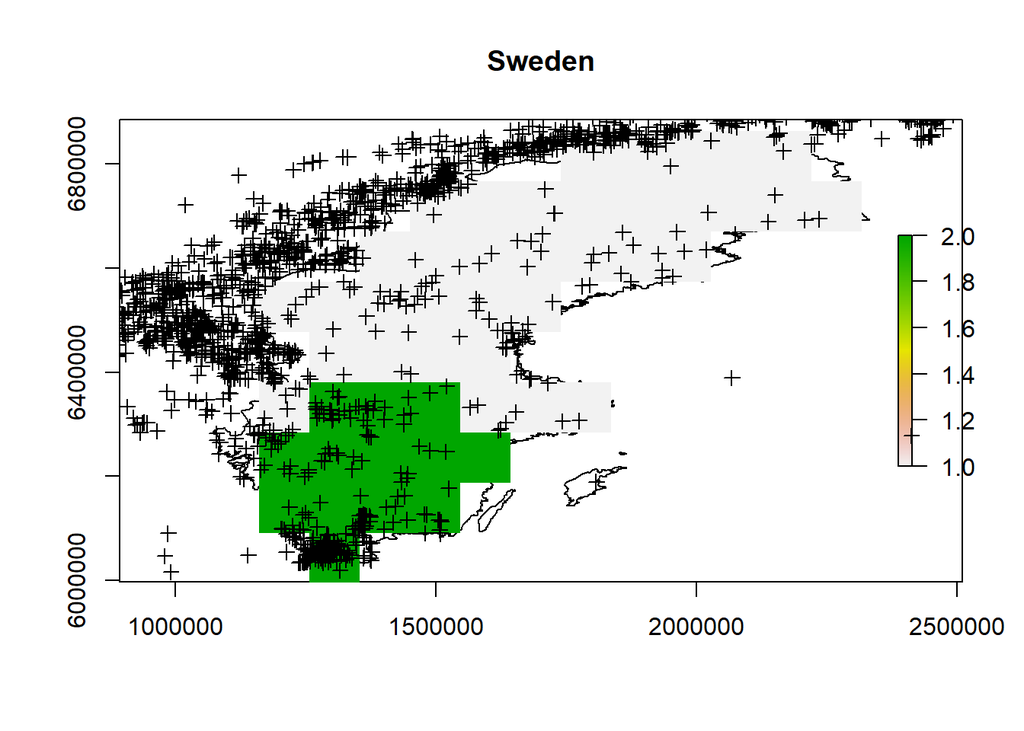

```r
plot(country_transformed_spatial,axes=T,main='Sweden')
plot(country_cells,add=T)
plot(species_occurrences_transformed,pch=3,add=T)
```

You have now finished the tutorial for day one. You can spend the rest of the day trying to create the nicest possible graph for the group and country you are working on and show/ brag on slack.